# Question 1: Covid

Austin Byrne

June 2023

### Abstract

Covid-19, understanding why some continents had higher cases but lower deaths.

```r
knitr::opts_chunk$set(echo = FALSE, message=FALSE, warning=FALSE)
pacman::p_load(modelsummary, gt, knitr, kableExtra, tidyverse)

install.packages("tinytex")
library(tinytex)
tinytex::install_tinytex()
```

```r
library(tidyverse)
list.files('C:/Users/austi/OneDrive/Desktop/Masters/Data Science/22582053/Question 1/code', full.names = T, recursive = T) %>% as.list() %>% walk(~source(.))
```

# Introduction

Covid-19 caused havok around the world. Covid-19 effected young and old individuals as they feared for their life as well as their loved ones. As total cases and deaths rose and months went on with no cure people feared for the worst. Luckly, goverments have been able to contain the various and lives are back to somewhat normal. This global pandemic provides for some intresting stats to look into. In this analysis I will provide insight into the total cases per continent and the total deaths per continent which can provide for some intresting narratives.

# 1 Data

# 2 obtaining the total cases, total deaths on the last date:

```r
#USing a function to obtain total cases and deaths
Final_total_covid_cases <- obtain_total_covid_casses_function(owid_covid_data)
print(Final_total_covid_cases)
```

```
## # A tibble: 6 × 2
##   continent     total_cases
##   <chr>               <dbl>
## 1 Africa           11958596
## 2 Asia            155063285
## 3 Europe          201018817
## 4 North America   101452674
## 5 Oceania           9303433
## 6 South America    58555494
```

```r
Final_total_covid_deaths <- obtain_total_deaths_function(owid_covid_data)
```

# 3 Comparing the effect of Covid-19 on different continents

## 3.1 Total cases

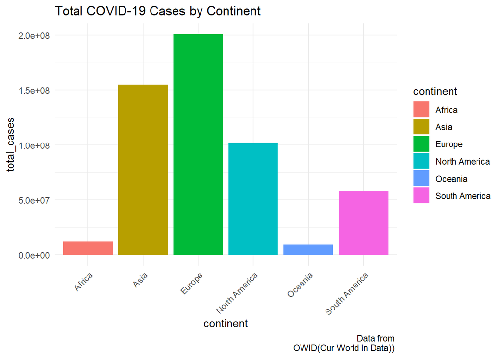

```r
covid_continent_data <- continent_comparer_function(owid_covid_data, continent) #In this line of code I use a function that groups by continent and then provides a summary for the total cases, total deaths and total new cases.

bar_plot_covid_data(Final_total_covid_cases)
```

## 3.2 Total deaths

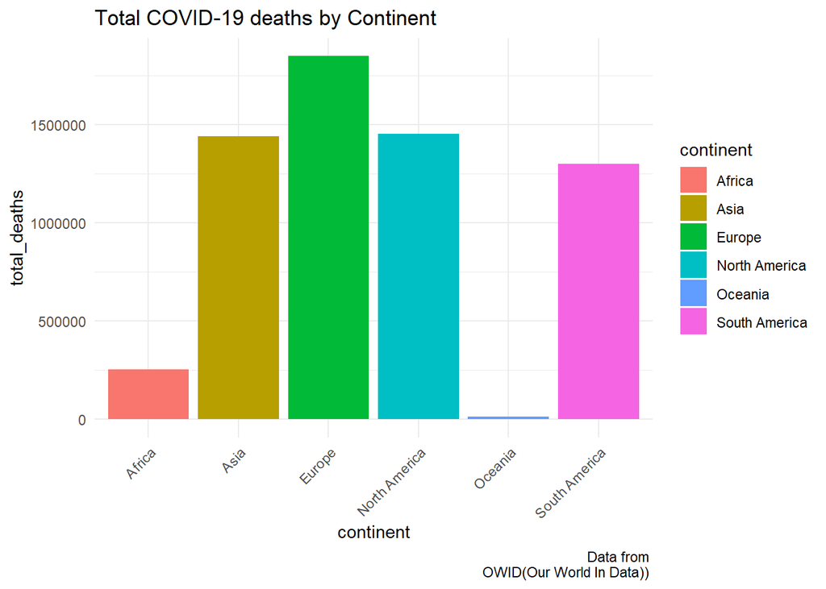

```r
bar_plot_covid_deaths_data(Final_total_covid_deaths)
```

When looking at the total deaths per continent we find some more interesting data. One might expect the same distribution as the one found in the first figure, More cases equals more deaths. However, this is not the case. South and North America now account for a larger proportion of the the deaths which means that they had a higher death rate then that of Europe or Asia. Another fact to pick up on is that Africa’s proportion has also increased meaning that Africa also had a larger death rate. Some interesting aspects to look into would be why did this happen? Why did some continents have high total cases but lower death rates? Is it down to over all health? Do these continents pride themselves on being health? Do they have better health care systems? Did they get vaccines first? There are many interesting aspects that can be followed up on after just looking into two simple plots.

# 4 Conclusion